# Autoencoder

Shan-Hung Wu & DataLab  
Fall 2018

In this lab, we are going to introduce Autoencoder and Manifold learning

## Autoencoder

Autoencoder is a popular unsupervised learning model, which is used to reduce data dimension or used in some end2end learning model, like img2img translation. Autoencoder has two compoments: encoder and decoder. Encoder learns to encode input data into code **c** (also called representation or embedding), while decoder learns to reconstruct input data from code **c**. When we have the trained encoder, we can use it to reduce the data dimension. Compared with other data dimension reduction method (e.g. PCA), it may be more efficient because it learn representation in different layer instead of a huge transformation. In addition, since autoencoder is a neural network model, it can learn non-linear mapping.

[figure not shown]

```python
%matplotlib inline
# Import libraries
import sys
import os
os.environ["CUDA_VISIBLE_DEVICES"] = '1'
import numpy as np
import matplotlib.pyplot as plt
from time import time
import tensorflow as tf
```

We will use MNIST dataset to demo autoencoder. In the following, we will show our setting of model, the reconstruction results and the manifold learning performance (which will be compared to denoising autoencoder latter).

Note: In MNIST dataset, although the pixels are ranged in [0,1], we recommend to use binary cross entropy loss to have sharper reconstructed results.

Some setting is referenced from [The Keras Blog: Autoencoder](https://blog.keras.io/building-autoencoders-in-keras.html)

```
origin data
```

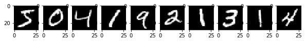

```
noisy data
```

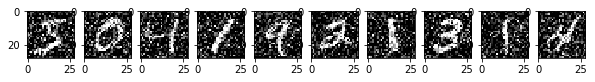

```python
from tensorflow.keras.datasets import mnist
# load data
(x_train, _),(x_test, _) = mnist.load_data()
x_train, x_test = x_train / 255.0, x_test / 255.0
x_valid = x_train[-5000:] # use final 5000 data as validation data
x_train = x_train[:-5000]

# Noise data
noise_factor = 0.4
x_train_noise = x_train + noise_factor * np.random.normal(loc=0., scale=1.0, size=x_train.shape)
x_valid_noise = x_valid + noise_factor * np.random.normal(loc=0., scale=1.0, size=x_valid.shape)
x_test_noise = x_test + noise_factor * np.random.normal(loc=0., scale=1.0, size=x_test.shape)

# Range of our dataset is [0,1]
x_train_noise = np.clip(x_train_noise, 0., 1.)
x_valid_noise = np.clip(x_valid_noise, 0., 1.)
x_test_noise = np.clip(x_test_noise, 0., 1.)

# show data
print('origin data')
fig, axs = plt.subplots(1, 10, figsize=(10,1))
for idx, ax in enumerate(axs):
    ax.imshow(x_train[idx], cmap='gray')
plt.show()
print('noisy data')
fig, axs = plt.subplots(1, 10, figsize=(10,1))
for idx, ax in enumerate(axs):
    ax.imshow(x_train_noise[idx], cmap='gray')
plt.show()
```

```python
class AutoEncoder(object):
    def __init__(self, lr=0.001, cost_function='bce', optimizer='adadelta'):

        self.lr = lr # learning rate
        self.cost_function = cost_function
        self.optimizer = optimizer
        self.build_model()

    def build_model(self):
        self.encoder_input = tf.placeholder(tf.float32, shape=[None, 28, 28], name='encoder_input')
        self.decoder_output = tf.placeholder(tf.float32, shape=[None, 28, 28], name='decoder_output')
        encoder_input = tf.reshape(self.encoder_input, [-1, 784])
        decoder_output = tf.reshape(self.decoder_output, [-1, 784])
        with tf.variable_scope('encoder'):
            hidden = tf.layers.dense(inputs=encoder_input, units=512, activation=tf.nn.relu)
            hidden = tf.layers.dense(hidden, units=256, activation=tf.nn.relu)
            hidden = tf.layers.dense(hidden, units=64, activation=tf.nn.relu)
            hidden = tf.layers.dense(hidden, units=16, activation=tf.nn.relu)
            self.encoded_embedding = hidden

        with tf.variable_scope('decoder'):
            hidden = tf.layers.dense(inputs=self.encoded_embedding, units = 64, activation=tf.nn.relu)
            hidden = tf.layers.dense(inputs=hidden, units = 256, activation=tf.nn.relu)
            hidden = tf.layers.dense(inputs=hidden, units = 512, activation=tf.nn.relu)
            outputs = tf.layers.dense(inputs=hidden, units = 784, name = 'recon_logits')

        def jacobian(ys, x):
            # return gradient dy/dx
            # Note: tf.gradients returns sum(dy/dx) for each x in xs, so we need to compute each y seperatedly.
            ys = tf.unstack(ys, axis = 1)
            jacobian = tf.stack([tf.gradients(y,x)[0] for y in ys], axis=-1)
            return jacobian
        self.jacobian = jacobian(self.encoded_embedding, self.encoder_input)

        ################## define cost function and optimizer ##################
        if self.cost_function == 'mse':
            self.reconstruct_x = tf.reshape(outputs, [-1, 28, 28])
            self.cost = tf.reduce_mean(tf.pow(decoder_output-outputs, 2))
        elif self.cost_function == 'bce':
            self.reconstruct_x = tf.reshape(tf.nn.sigmoid(outputs), [-1, 28, 28])
            self.cost = tf.reduce_mean(tf.nn.sigmoid_cross_entropy_with_logits(
                                                            labels=decoder_output,
                                                            logits=outputs))
        else:
            raise NotImplementedError

        if self.optimizer == 'adadelta':
            self.optimize_op = tf.train.AdadeltaOptimizer(self.lr).minimize(self.cost)
        elif self.optimizer == 'adam':
            self.optimize_op = tf.train.AdamOptimizer(self.lr).minimize(self.cost)
        elif self.optimizer == 'rmsprop':
            self.optimize_op = tf.train.RMSPropOptimizer(self.lr).minimize(self.cost)
        else:
            raise NotImplementedError

    def train(self, sess, x_train, x_valid, x_test, x_train_output, x_valid_output, x_test_output,
              n_epoch=200, batch_size=100, patience=5):
        t0 = time()
        train_costs_per_epoch = []
        valid_costs_per_epoch = []
        best_cost = np.inf
        counter = 0
        def iter_data(*data, **kwargs):
            size = kwargs.get('batch_size', 128)
            try:
                n = len(data[0])
            except:
                n = data[0].shape[0]
            batches = int(n / size)
            if n % size != 0:
                batches += 1

            for b in range(batches):
                start = b * size
                end = (b + 1) * size
                if end > n:
                    end = n
                if len(data) == 1:
                    yield data[0][start:end]
                else:
                    yield tuple([d[start:end] for d in data])
        for epoch in range(n_epoch):
            t = time()
            shuffle_idx = np.random.permutation(len(x_train))
            x_train = x_train[shuffle_idx]
            x_train_output = x_train_output[shuffle_idx]
            train_costs = []
            valid_costs = []

            # train
            for input_batch, output_batch in iter_data(x_train, x_train_output, batch_size=batch_size):
                feed_dict = {
                    self.encoder_input: input_batch,
                    self.decoder_output: output_batch
                }
                _, cost = sess.run([self.optimize_op, self.cost], feed_dict=feed_dict)
                train_costs.append(cost)

            # validation
            for input_batch, output_batch in iter_data(x_valid, x_valid_output, batch_size=batch_size):
                cost = sess.run(self.cost, feed_dict={self.encoder_input: input_batch, self.decoder_output: output_batch})
                valid_costs.append(cost)
#             print('epoch{}, train_cost: {}, valid_cost: {}, time_passed: {}'.format(
#                   epoch, np.mean(train_costs), np.mean(valid_costs), time()-t))
            train_costs_per_epoch.append(np.mean(train_costs))
            valid_costs_per_epoch.append(np.mean(valid_costs))

            # early stop
            if best_cost > np.mean(valid_costs):
                best_cost = np.mean(valid_costs)
                counter = 0
            else:
                counter += 1
            if counter >= patience:
                print('epoch{}, train_cost: {}, valid_cost: {}, time_passed: {}'.format(
                  epoch, np.mean(train_costs), np.mean(valid_costs), time()-t))
                print('early stop at {} epoch'.format(epoch))
                break
        # test
        test_costs = []
        for input_batch, output_batch in iter_data(x_test, x_test_output, batch_size=batch_size):
            cost = sess.run(self.cost, feed_dict={self.encoder_input: input_batch, self.decoder_output: output_batch})
            test_costs.append(cost)
        print('final test_cost: {}'.format(np.mean(test_costs)))
        return train_costs_per_epoch, valid_costs_per_epoch

    def encode(self, sess, inputs):
        return sess.run(self.encoded_embedding, feed_dict={self.encoder_input: inputs})

    def reconstruct(self, sess, inputs):
        return sess.run(self.reconstruct_x, feed_dict={self.encoder_input: inputs})

    def get_jaco_matrix(self, sess, xbatch):
        jaco_matrix = []
        feed_dict = {
            self.encoder_input: xbatch,
        }
        jacobian_matrix_batch = sess.run(self.jacobian, feed_dict=feed_dict)
        return jacobian_matrix_batch
```

```python
tf.reset_default_graph()
np.random.seed(123)
tf.set_random_seed(123)
autoencoder = AutoEncoder(optimizer='adadelta', lr=1)

config = tf.ConfigProto()
config.gpu_options.allow_growth = True
sess = tf.Session(config=config)
sess.run(tf.global_variables_initializer())
train_costs_per_epoch, valid_costs_per_epoch = autoencoder.train(sess, x_train, x_valid, x_test, x_train, x_valid, x_test)
```

```
epoch89, train_cost: 0.09277332574129105, valid_cost: 0.09557944536209106, time_passed: 1.0937001705169678
early stop at 89 epoch
final test_cost: 0.09446466714143753
```

Plot the learning curve to check if the training is converged.

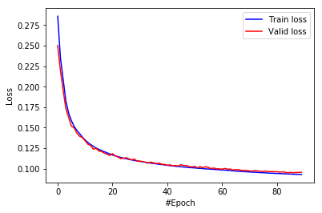

```python
plt.plot(range(len(train_costs_per_epoch)), train_costs_per_epoch, color='blue', label='Train loss')
plt.plot(range(len(valid_costs_per_epoch)), valid_costs_per_epoch, color='red', label='Valid loss')
plt.legend(loc="upper right")
plt.xlabel('#Epoch')
plt.ylabel('Loss')
plt.show()
```

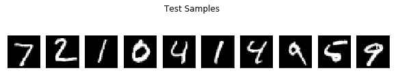

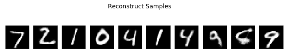

```python
n = 10
orig_imgs = x_test[:n]
recon_imgs = autoencoder.reconstruct(sess, orig_imgs)

def plot_imgs(imgs, n, title=None):
    fig, axs = plt.subplots(1, n, figsize=(n, 2))
    for i in range(n):
        axs[i].imshow(imgs[i], cmap='gray')
        axs[i].get_xaxis().set_visible(False)
        axs[i].get_yaxis().set_visible(False)
    if title is not None:
        fig.suptitle(title)
    plt.show()
plot_imgs(orig_imgs, n=n, title='Test Samples')
plot_imgs(recon_imgs, n=n, title='Reconstruct Samples')
```

### Tangent vectors & Jacobian matrix

Autoencoder can also learn manifold. To justify this, we can plot the tangent vectors.

Extract tangent vectors:

1. Sample a data $x_0$
2. Compute Jacobian matrix $J(x_0)$ of $f: Image \mapsto Code$
3. Compute SVD of $J(x_0)$, $J(x_0) = U\Sigma V^T$.
4. Pick top K eigenvectors from V as tangent vectors.

In the following demo, we use the first sample in testing data, which is a digit 7 image.

```python
def tangent_vecs(jaco_matrix):
    # get jacobian matrix of size (code_size * img_dim)
    # get tangent vectors via SVD
    U, s, V = np.linalg.svd(jaco_matrix, full_matrices=False)
    plt.bar(range(s.shape[0]), s, alpha=0.5)
    plt.ylabel('SVD values')
    plt.xlabel('Index')
    plt.tight_layout()
    plt.show()
    return U, s, V
```

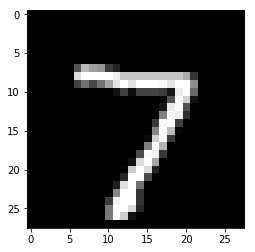

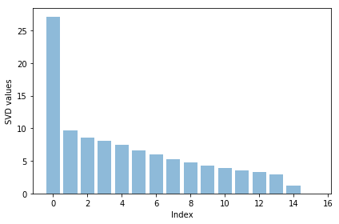

```
(16, 16)
(16,)
(16, 784)
```

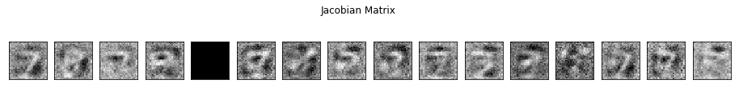

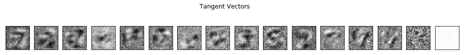

```python
img = x_test[:1]
plt.imshow(img[0],cmap='gray')
plt.show()

jaco_matrix = autoencoder.get_jaco_matrix(sess, img)[0] # shape (28,28,16)
jaco_matrix = jaco_matrix.transpose([2,0,1]) # shape (16,28,28)
U, s, V = tangent_vecs(jaco_matrix.reshape([-1, 28*28]))
print(U.shape)
print(s.shape)
print(V.shape)
plot_imgs(jaco_matrix, n=len(jaco_matrix), title = 'Jacobian Matrix')
plot_imgs(V.reshape([-1,28,28]), n=len(V), title = 'Tangent Vectors')
```

## Denoising Autoencoder and Manifold Learning

As the above result, autoencoder can learn manifold. However, it's not good enough. We can improve it by adding regularization term for Jacobian matrix of reconstruction or simply adding noise to data, to make the codes more robust to input images. You can find more details from this [paper](https://www.iro.umontreal.ca/~vincentp/Publications/denoising_autoencoders_tr1316.pdf).

[figure not shown]

Given appropriate noisy magnitude, denoising autoencoder can learn the direction toward the data manifold, mapping noisy data to original one.

```python
tf.reset_default_graph()
np.random.seed(123)
tf.set_random_seed(123)
autoencoder = AutoEncoder(optimizer='adadelta', lr = 1, cost_function='bce')

config = tf.ConfigProto()
config.gpu_options.allow_growth = True
sess = tf.Session(config=config)
sess.run(tf.global_variables_initializer())
train_costs_per_epoch, valid_costs_per_epoch = autoencoder.train(sess, x_train_noise, x_valid_noise, x_test_noise, x_train, x_valid, x_test, patience=10)
```

```
epoch98, train_cost: 0.10210052132606506, valid_cost: 0.11260342597961426, time_passed: 1.1127660274505615
early stop at 98 epoch
final test_cost: 0.1117234155535698
```

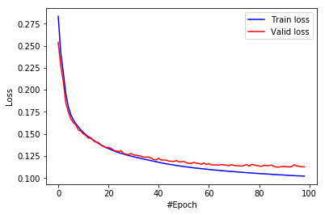

```python
plt.plot(range(len(train_costs_per_epoch)), train_costs_per_epoch, color='blue', label='Train loss')
plt.plot(range(len(valid_costs_per_epoch)), valid_costs_per_epoch, color='red', label='Valid loss')
plt.legend(loc="upper right")
plt.xlabel('#Epoch')
plt.ylabel('Loss')
plt.show()
```

The reconstruction results here, compared to the above ones, are little more blurry but we can still distinguish each different digits.

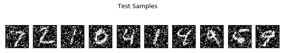

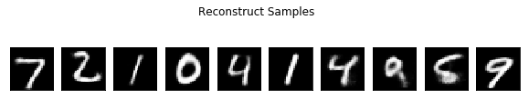

```python
n = 10

orig_imgs = x_test_noise[:n]
recon_imgs = autoencoder.reconstruct(sess, orig_imgs)

plot_imgs(orig_imgs, n=n, title='Test Samples')
plot_imgs(recon_imgs, n=n, title='Reconstruct Samples')
```

Plot the Jacobian matrix and tangent vectors given a single digit 7 image.

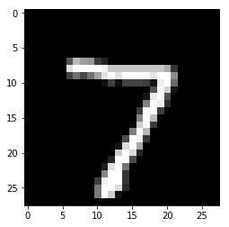

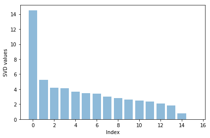

```
(16, 16)
(16,)
(16, 784)
```

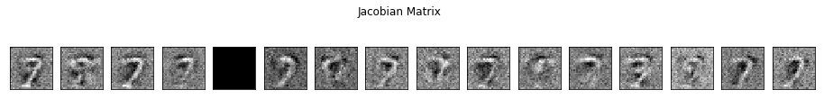

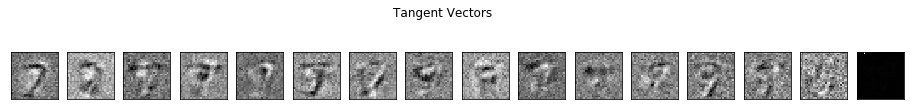

```python
img = x_test[:1]
plt.imshow(img[0],cmap='gray')
plt.show()

jaco_matrix = autoencoder.get_jaco_matrix(sess, img)[0] # shape (28,28,16)
jaco_matrix = jaco_matrix.transpose([2,0,1]) # shape (16,28,28)
U, s, V = tangent_vecs(jaco_matrix.reshape([-1, 28*28]))
print(U.shape)
print(s.shape)
print(V.shape)
plot_imgs(jaco_matrix, n=len(jaco_matrix), title = 'Jacobian Matrix')
plot_imgs(V.reshape([-1,28,28]), n=len(V), title = 'Tangent Vectors')
```

As the result, we can see that the tangent vectors are more sharper.

## Assignment

In this assignment you need to train **deepfakes** model, which can be used to transfer someone's face to another person. The main idea behind deepfake is to train a autoencoder in which one encoder is shared with two decoder. The first decoder learn to use encoded embedding to decode first person while second decoder learn to use encoded embedding to deocde second person. The encoder learn to encoded shared knowledge from both people, e.g. eye position, mouth position, etc. At testing time, we can then use first decoder to decode image of second person, and vice versa.

#### Todo:

1. Train an autoencoder model on [Cage/Trump](https://drive.google.com/file/d/1FQWGbFhVy3p16SDTZXhKKEPvT8b-QPPm/view?usp=sharing) dataset.
2. Complete encoder and decoder.

#### Goal

1. Reconstruct Cage/Trump by Trump/Cage, result should look good.
2. Come up or survey some applications of autoencoder. Write in or paste link in notebook.
3. Write a brief report about what you learn.